# Pandas

### Why Pandas

Pandas is one of the most powerful data manipulation tools out there but when a data scientist can leverage the power of indexing to his advantage, it makes pandas the best data manipulation tool out there!

### DataFrame Basics

*Dataframe* is a main object in Pandas. What’s cool about Pandas is that it takes data (like a CSV or JSON file, or a SQL database) and creates a Python object with **rows** and **columns**. It is used to reprsent data with rows and columns (tabular or excel spreadsheet like data).

```python
from IPython.display import Image

Image("EDA.png")
```

## 6 Parts of Pandas

1. Importing Data and Reading Data
2. Summarizing Data (Statistics)
3. Manipulating Data / Cleaning Data
4. Selecting Data / Subsetting Data
5. Grouping and Filtering Data
6. Combining Datasets

# Getting Started

## Import Libraries

**Pandas:** Use for data manipulation and data analysis.  
**Numpy:** fundamental package for scientific computing with Python.  
**Matplotlib and Seaborn :** For plotting and visualization.  
**Scikit-learn :** For the data preprocessing techniques and algorithms.

```python
# Importing required Packages
import pandas as pd
import numpy as np

import matplotlib
import matplotlib.pyplot as plt
import seaborn as sns
%matplotlib inline

import warnings
warnings.filterwarnings("ignore")
from IPython.display import Image
```

## Pandas Data Structure

Series

DataFrame

### What is Series

```python
## Anand,Mukesh,Ramesh,Shiva

age_np = np.array([23,56,67,89])
age_np
```

```python
age_np[0]
```

```python
names = ["Anand","Mukesh","Ramesh","Shiva"]
age_series = pd.Series(data=age_np,index=names)
age_series
```

```python
age_series["Mukesh"]
```

### Create DataFrames

```python
english = [34,56,78,66]
S1 =pd.Series(data=english,index=names)
S1
```

```python
maths = [76,45,97,56]
S2 = pd.Series(data=maths,index=names)
S2
```

```python
df =  pd.DataFrame({"English_marks" : S1,"Maths_marks":S2})
df
```

```python
data = {'Name':['Tom', 'nick', 'krish', 'jack'], 'Age':[20, 21, 19, 18]}
df = pd.DataFrame(data)
```

```python
###############---------###############
```

```python
data = [['tom', 10], ['nick', 15], ['juli', 14]]
df = pd.DataFrame(data, columns = ['Name', 'Age'])
```

```python
data = [{'a': 1, 'b': 2, 'c':3}, {'a':10, 'b': 20, 'c': 30}]
df = pd.DataFrame(data)
```

```python
Name = ['tom', 'krish', 'nick', 'juli']
Age = [25, 30, 26, 22]
list_of_tuples = list(zip(Name, Age))
df = pd.DataFrame(list_of_tuples, columns = ['Name', 'Age'])
```

```python
df =  pd.DataFrame({"col1" : [1,2,3],"col2":[5,6,7]})
```

## Importing Data

```python
Image("files_read.png")
```

### Import .csv files from a local machine

Use the file path: file_path = "/home//Desktop/Project/"

```python
# Read Loan Dataset
df = pd.read_csv("train.csv")
df.head()
```

```python
df.tail()
```

### Importing Files from a web url

```python
import ssl

ssl._create_default_https_context = ssl._create_unverified_context

url = 'https://raw.githubusercontent.com/edyoda/data-science-complete-tutorial/master/Data/HR_comma_sep.csv.txt'
df_hr = pd.read_csv(url)
df_hr
```

### Get the data from a excel

```python
df_sales = pd.read_excel('data-science-complete-tutorial/Data/sales_info.xlsx')

df_sales
```

### Exploring pd.read_csv()

Read_csv parameters: https://honingds.com/blog/pandas-read_csv/

#### **sep = "," by default :**

Specify separator if it not a comma

```python
Image("sep.png")
```

Use sep = “|” as shown below

```python
Image("sep1.png")
```

#### **header :**

Use pandas read_csv header to specify which line in your data is to be considered as header.

```python
Image("data_header.png")
```

```python
Image("header_0.png")
```

**header = 1 means consider second line of the dataset as header.**

```python
Image("header_1.png")
```

#### **index_col :**

Use this argument to specify the row labels to use. If you set index_col to 0, then the first column of the dataframe will become the row label.

```python
Image("index_col.png")
```

#### **use_cols :**

Use pandas usecols when you want to load specific columns into dataframe. When your input dataset contains a large number of columns, and you want to load a subset of those columns into a dataframe , then usecols will be very useful

```python
Image("usecols.png")
```

#### **nrows :**

If you want to read a limited number of rows, instead of all the rows in a dataset, use nrows. This is especially useful when reading a large file into a pandas dataframe.

```python
Image("nrows.png")
```

```python
### Standard practice
data_original = df.copy()
```

# HIGH LEVEL DATA UNDERSTANDING

### Functions

These functions are the most common tools used when trying to summarize your data

- **df.head(n)** — Returns the first n rows of your DataFrame. Having a blank argument will display the first 5 by default
- **df.tail(n)** — Returns the last n rows of your DataFrame. Having a blank argument will display the last 5 by default
- **df.shape()** — Displays the number of rows and columns in your DataFrame
- **df.describe()** — Dispalys a statistical summary for numerical columns
- **df.describe(include=['object'])** — Displays a statistical summary for all object (string) columns
- **df.describe(include='all')** — Displays a statistical summary for all columns
- **df.mean()** — Returns the mean of all columns
- **df.median()** — Returns the median of all columns
- **df.std()** — Returns the standard deviation of all columns
- **df.max()** — Returns the highest value in each column
- **df.min()** — Returns the lowest value in each column
- **df.dtypes** - Returns the data types of each colulmn

### See the first 5 entries

data.head()

```python
df.head()
```

### See the last 5 entries

data.tail()

```python
df.tail()
```

### What is the number of observations & features in the dataset?

data.shape

#### Shape of Dataframe

# will give you both (observations/rows, columns)

```python
df.shape
```

#### No. of observations(Rows)

# will give you only the observations/rows number

```python
df.shape[0]
```

#### No. of Features(Columns)

# will give you the # features/columns number

```python
df.shape[1]
```

### Print the name of all the columns.

```python
df.columns
```

We have 12 independent variables and 1 target variable, i.e. Loan_Status in the loan_data dataset

```python
Image('Datacolumns.PNG')
```

### What is the name of 3rd column?

```python
chipo.columns[3]
```

### How is the dataset indexed?

```python
chipo.index
```

### Datatype of Features

```python
df.dtypes
```

**object:** Object format means variables are categorical. Categorical variables in our dataset are: Loan_ID, Gender, Married, Dependents, Education, Self_Employed, Property_Area, Loan_Status

**int64:** It represents the integer variables. ApplicantIncome is of this format.

### Features information

```python
chipo.info() #Columns: 163 entries
```

### Describing Data

```python
df.describe(include='all')
```

# LOW LEVEL DATA UNDERSTANDING

## Univariate Analysis

### Categorical Feature

#### Unique value in a column

```python
chipo['item_name'].unique()
```

#### No. of unique value in a column

```python
chipo['item_name'].nunique()
```

```python
df['Loan_Status'].value_counts()
```

```python
# Normalize can be set to True to print proportions instead of number
df['Loan_Status'].value_counts(normalize=True)
```

#### Bar chart

```python
df['Loan_Status'].value_counts().plot(kind='bar')
```

The loan of 422(around 69%) people out of 614 was approved.

Different types of variables are Categorical, ordinal and numerical.

**Categorical features:** These features have categories (Gender, Married, Self_Employed, Credit_History, Loan_Status)

**Ordinal features:** Variables in categorical features having some order involved (Dependents, Education, Property_Area)

**Numerical features:** These features have numerical values (ApplicantIncome, CoapplicantIncome, LoanAmount, Loan_Amount_Term)

#### Pie chart

```python
df['Gender'].value_counts().plot(kind='pie')
```

### Numeric Feature

```python
df['LoanAmount'].max()
```

```python
df['LoanAmount'].describe()
```

#### Histogram

```python
df['ApplicantIncome'].plot(kind="hist")
```

#### Density plot

```python
df['ApplicantIncome'].plot(kind="kde")
```

#### Box Plot

```python
df['ApplicantIncome'].plot(kind="box")
```

## Bivariate Analysis

```python
# Importing required Packages
import pandas as pd
import numpy as np

import matplotlib
import matplotlib.pyplot as plt
import seaborn as sns
%matplotlib inline

import warnings
warnings.filterwarnings("ignore")
from IPython.display import Image
```

```python
import pandas as pd

df = pd.read_csv("train.csv")
```

### 2 Categorical Variable

#### Cross table

pandas.crosstab(column #1 ,column #2 , margins = True , normalize = 'index')  
margins -----------------> to get total across columns & rows .  
normalize = 'index' -----> to get percentage across rows .  
normalize = 'columns' -----> to get percentage across columns .

```python
pd.crosstab(df['Loan_Status'],df['Gender'])
```

| Gender Loan_Status | Female | Male |
| --- | --- | --- |
| N | 37 | 150 |
| Y | 75 | 339 |

```python
pd.crosstab(df['Loan_Status'],df['Gender'],margins=True)
```

| Gender Loan_Status | Female | Male | All |
| --- | --- | --- | --- |
| N | 37 | 150 | 187 |
| Y | 75 | 339 | 414 |
| All | 112 | 489 | 601 |

```python
pd.crosstab(df['Loan_Status'],df['Gender'],normalize="index")*100
```

| Gender Loan_Status | Female | Male |
| --- | --- | --- |
| N | 19.786096 | 80.213904 |
| Y | 18.115942 | 81.884058 |

```python
pd.crosstab(df['Loan_Status'],df['Gender'],normalize="columns")*100
```

| Gender Loan_Status | Female | Male |
| --- | --- | --- |
| N | 33.035714 | 30.674847 |
| Y | 66.964286 | 69.325153 |

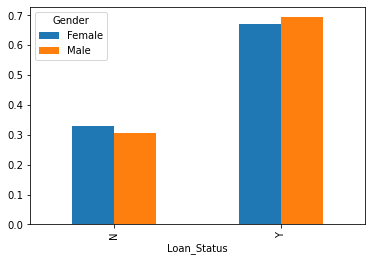

```python
pd.crosstab(df['Loan_Status'],df['Gender'],normalize="columns").plot(kind='bar')
```

```python
df.head()
```

|  | Loan_ID | Gender | Married | Dependents | Education | Self_Employed | ApplicantIncome | CoapplicantIncome | LoanAmount | Loan_Amount_Term | Credit_History | Property_Area | Loan_Status |
| --- | --- | --- | --- | --- | --- | --- | --- | --- | --- | --- | --- | --- | --- |
| 0 | LP001002 | Male | No | 0 | Graduate | No | 5849 | 0.0 | NaN | 360.0 | 1.0 | Urban | Y |
| 1 | LP001003 | Male | Yes | 1 | Graduate | No | 4583 | 1508.0 | 128.0 | 360.0 | 1.0 | Rural | N |
| 2 | LP001005 | Male | Yes | 0 | Graduate | Yes | 3000 | 0.0 | 66.0 | 360.0 | 1.0 | Urban | Y |
| 3 | LP001006 | Male | Yes | 0 | Not Graduate | No | 2583 | 2358.0 | 120.0 | 360.0 | 1.0 | Urban | Y |
| 4 | LP001008 | Male | No | 0 | Graduate | No | 6000 | 0.0 | 141.0 | 360.0 | 1.0 | Urban | Y |

```python
df.dtypes
```

```
Loan_ID               object
Gender                object
Married               object
Dependents            object
Education             object
Self_Employed         object
ApplicantIncome        int64
CoapplicantIncome    float64
LoanAmount           float64
Loan_Amount_Term     float64
Credit_History        object
Property_Area         object
Loan_Status           object
dtype: object
```

```python
df['Credit_History'] = df['Credit_History'].astype('object')
```

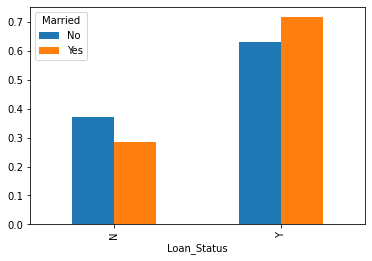

```python
pd.crosstab(df['Loan_Status'],df['Married'],normalize="columns").plot(kind='bar')
```

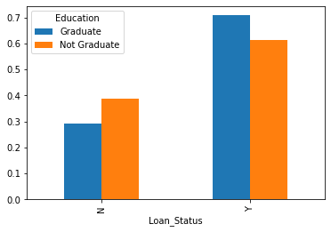

```python
pd.crosstab(df['Loan_Status'],df['Education'],normalize="columns").plot(kind='bar')
```

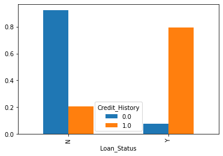

```python
pd.crosstab(df['Loan_Status'],df['Credit_History'],normalize="columns").plot(kind='bar')
```

```python
df.head()
```

### 2 Numeric Variable

#### Correlation

Correlation is Positive when the values increase together, and

Correlation is Negative when one value decreases as the other increases  
A correlation is assumed to be linear (following a line).

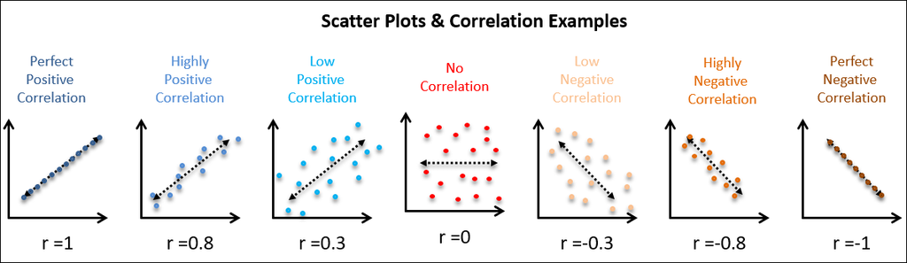

```python
Image("corr.png")
```

Correlation can have a value:

1 is a perfect positive correlation

0 is no correlation (the values don't seem linked at all)

-1 is a perfect negative correlation

```python
df.corr()
```

|  | ApplicantIncome | CoapplicantIncome | LoanAmount | Loan_Amount_Term |
| --- | --- | --- | --- | --- |
| ApplicantIncome | 1.000000 | -0.116605 | 0.570909 | -0.045306 |
| CoapplicantIncome | -0.116605 | 1.000000 | 0.188619 | -0.059878 |
| LoanAmount | 0.570909 | 0.188619 | 1.000000 | 0.039447 |
| Loan_Amount_Term | -0.045306 | -0.059878 | 0.039447 | 1.000000 |

```python
df.head()
```

|  | Loan_ID | Gender | Married | Dependents | Education | Self_Employed | ApplicantIncome | CoapplicantIncome | LoanAmount | Loan_Amount_Term | Credit_History | Property_Area | Loan_Status |
| --- | --- | --- | --- | --- | --- | --- | --- | --- | --- | --- | --- | --- | --- |
| 0 | LP001002 | Male | No | 0 | Graduate | No | 5849 | 0.0 | NaN | 360.0 | 1.0 | Urban | Y |
| 1 | LP001003 | Male | Yes | 1 | Graduate | No | 4583 | 1508.0 | 128.0 | 360.0 | 1.0 | Rural | N |
| 2 | LP001005 | Male | Yes | 0 | Graduate | Yes | 3000 | 0.0 | 66.0 | 360.0 | 1.0 | Urban | Y |
| 3 | LP001006 | Male | Yes | 0 | Not Graduate | No | 2583 | 2358.0 | 120.0 | 360.0 | 1.0 | Urban | Y |
| 4 | LP001008 | Male | No | 0 | Graduate | No | 6000 | 0.0 | 141.0 | 360.0 | 1.0 | Urban | Y |

```python
df["ApplicantIncome_INR"] = df['ApplicantIncome'] * 77
```

```python
df.head()
```

|  | Loan_ID | Gender | Married | Dependents | Education | Self_Employed | ApplicantIncome | CoapplicantIncome | LoanAmount | Loan_Amount_Term | Credit_History | Property_Area | Loan_Status | ApplicantIncome_INR |
| --- | --- | --- | --- | --- | --- | --- | --- | --- | --- | --- | --- | --- | --- | --- |
| 0 | LP001002 | Male | No | 0 | Graduate | No | 5849 | 0.0 | NaN | 360.0 | 1.0 | Urban | Y | 450373 |
| 1 | LP001003 | Male | Yes | 1 | Graduate | No | 4583 | 1508.0 | 128.0 | 360.0 | 1.0 | Rural | N | 352891 |
| 2 | LP001005 | Male | Yes | 0 | Graduate | Yes | 3000 | 0.0 | 66.0 | 360.0 | 1.0 | Urban | Y | 231000 |
| 3 | LP001006 | Male | Yes | 0 | Not Graduate | No | 2583 | 2358.0 | 120.0 | 360.0 | 1.0 | Urban | Y | 198891 |
| 4 | LP001008 | Male | No | 0 | Graduate | No | 6000 | 0.0 | 141.0 | 360.0 | 1.0 | Urban | Y | 462000 |

```python
df.corr()
```

|  | ApplicantIncome | CoapplicantIncome | LoanAmount | Loan_Amount_Term | ApplicantIncome_INR |
| --- | --- | --- | --- | --- | --- |
| ApplicantIncome | 1.000000 | -0.116605 | 0.570909 | -0.045306 | 1.000000 |
| CoapplicantIncome | -0.116605 | 1.000000 | 0.188619 | -0.059878 | -0.116605 |
| LoanAmount | 0.570909 | 0.188619 | 1.000000 | 0.039447 | 0.570909 |
| Loan_Amount_Term | -0.045306 | -0.059878 | 0.039447 | 1.000000 | -0.045306 |
| ApplicantIncome_INR | 1.000000 | -0.116605 | 0.570909 | -0.045306 | 1.000000 |

```python
LTI(Loan Amount to Income ratio) = LoanAmount/ApplicantIncome

Person 1 : Income=1,00,000 USD & Loan= 10000
LTI = 10 %

Person 2 : Income=15000 USD & Loan= 10000
LTI = 66 %
```

```
  File "<ipython-input-27-37a010a37d69>", line 1
    LTI(Loan Amount to Income ratio) = LoanAmount/ApplicantIncome
             ^
SyntaxError: invalid syntax
```

```python
df['LTI'] = (df["LoanAmount"]/df["ApplicantIncome"])*100
```

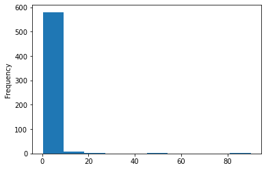

```python
df['LTI'].plot(kind='hist')
```

```python
df['LTI'].describe()
```

```
count    592.000000
mean       3.830616
std        5.582744
min        0.301614
25%        2.357604
50%        3.086484
75%        4.256322
max       90.000000
Name: LTI, dtype: float64
```

```python
10000*0.3/100
```

```
30.0
```

```python
df[df["LTI"]>= 90]
```

|  | Loan_ID | Gender | Married | Dependents | Education | Self_Employed | ApplicantIncome | CoapplicantIncome | LoanAmount | Loan_Amount_Term | Credit_History | Property_Area | Loan_Status | ApplicantIncome_INR | LTI |
| --- | --- | --- | --- | --- | --- | --- | --- | --- | --- | --- | --- | --- | --- | --- | --- |
| 216 | LP001722 | Male | Yes | 0 | Graduate | No | 150 | 1800.0 | 135.0 | 360.0 | 1.0 | Rural | N | 11550 | 90.0 |

#### Correlation plot

```python
Image("no_corr.png")
```

#### Solution : Predictive Power Score(PPS)

It works on both Linear and Non-Linear Relationships

Can be applied to both Numeric and Categorical columns

It finds more patterns in the data.

```python
!pip install ppscore
import ppscore as pps

pps.matrix(df)
```

[output not shown]

### Categorical & Numeric Feature

# Pandas without Coding

## Pandas Profiling

```python
import pandas_profiling
pandas_profiling.ProfileReport(df)
```

## Pandas GUI Demo

PandasGUI Demo : https://www.youtube.com/watch?v=NKXdolMxW2Y

## Bamboolib

Bamboolib Link : https://docs.bamboolib.8080labs.com/

https://hub.mybinder.turing.ac.uk/user/8080labs-bamboo-binder_template-g7hejlwr/notebooks/bamboolib_demo_titanic.ipynb

# Manipulating / Cleaning Data

[figure not shown]

Cleaning the data involves you to throw away, replace, and/or fill missing values/errors

### Functions

- **df.isnull().sum()** — Used to display the total amount of missing values in your columns
- **df.columns** — Displays a list of your column names
- **df.dropna()** — drop every NULL value.
- **df.columns = ['col_name1','col_name2','col_name3']** — Allows you to replace your columns with a new name
- **df.rename(columns={'old_name1':'new_name1', 'old_name2':'new_name2'})** — Allows you to rename certain columns directly
- **df.fillna(x)** — Repalces every null value in your table with x (could be a string value or numeric value)

## Duplicates

### Check Duplicates

```python
df = pd.read_csv('train.csv')
```

### Remove Duplicates

## Missing Values

### Missing Values identification

There are missing values in Gender, Married, Dependents, Self_Employed, LoanAmount, Loan_Amount_Term and Credit_History features.

For numerical variables: imputation using mean or median  
For categorical variables: imputation using mode

### Missing Value Treatment

Two stratagies

Fill the missing values

Delete the rows with missing values

### Drop NULL Values

```python
toy = pd.DataFrame({"name": ['Alfred', 'Batman', 'Catwoman'],
                   "toy": [np.nan, 'Batmobile', 'Bullwhip'],
                   "born": [pd.NaT, pd.Timestamp("1940-04-25"),
                            pd.NaT]})
```

### Replace NULL Value

# Writing a Dataframe to csv/excel